# Mesurer l’effet du discours (Macron 13 avril)

## Diagnostic de la série

from https://rstudio-pubs-static.s3.amazonaws.com/9428_1197bd003ebd43c49b429f22ea4f36e5.html

https://rpubs.com/sinhrks/plot_tsstats

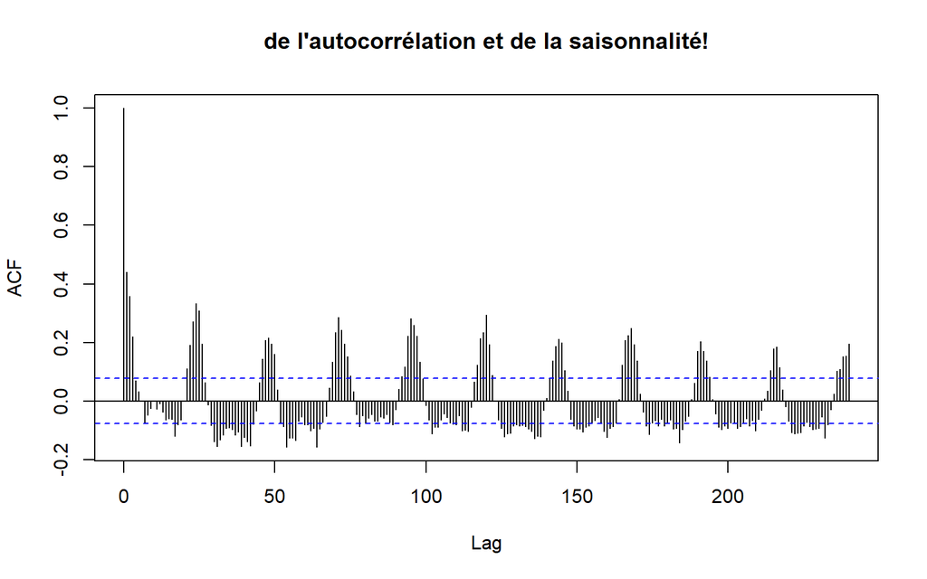

```r
acf(coredata(ts),lag.max = 240, main="de l'autocorrélation et de la saisonnalité!")
```

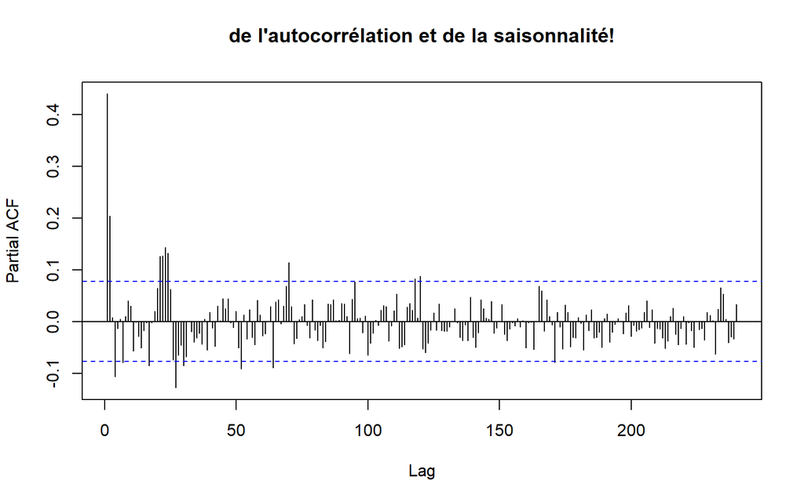

```r
pacf(coredata(ts),lag.max = 240, main="de l'autocorrélation et de la saisonnalité!")
```

```r
mspect <- spec.pgram(coredata(ts))
```

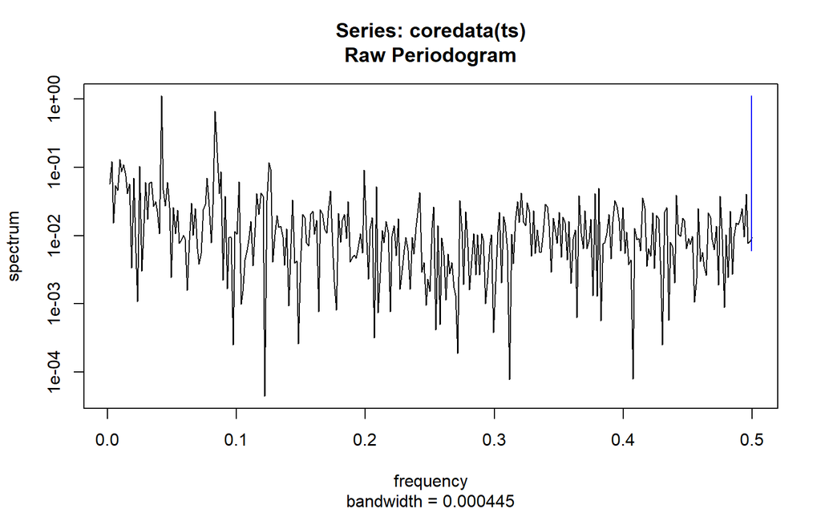

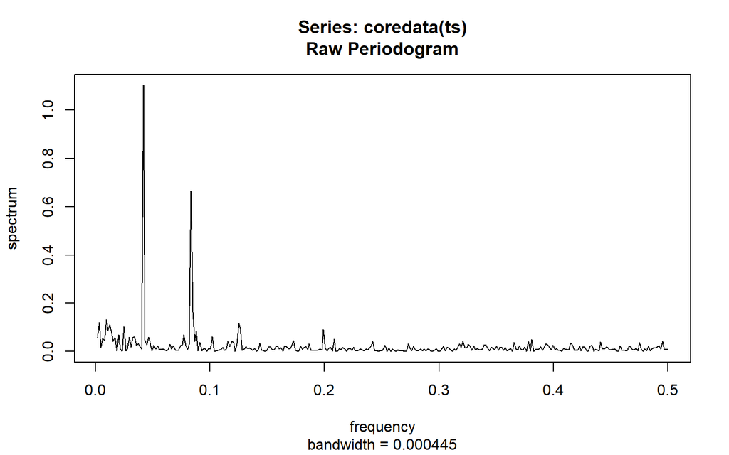

```r
plot(mspect, log = "no")
```

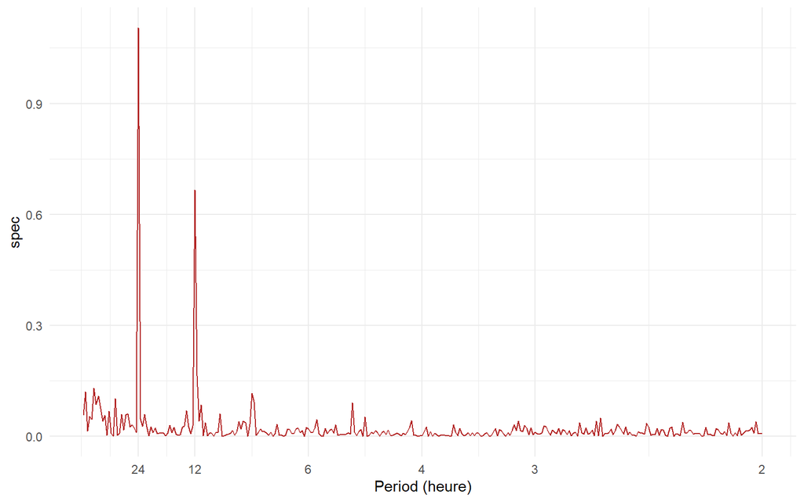

```r
#avec lissage
#k = kernel("daniell", c(5,5))
#smooth.spec <- spec.pgram(coredata(ts), kernel = k, taper = 0)

spec.df <- data.frame(freq = mspect$freq, spec = mspect$spec)

day.period <- rev(c(1/24,1/12, 1/6,1, 2, 3, 4, 6, 12, 24))
day.labels <- rev(c("1/24","1/12", "1/6","1", "2", "3","4", "6", "12", "24"))
yrs.freqs <- 1/day.period  #Convert annual period to annual freq, and then to monthly freq
mspect$period <- 1/spec.df$freq

ggplot(data = spec.df)+ geom_line(aes(x = freq, y = spec),color="firebrick") + scale_x_continuous("Period (heure)",
    breaks = yrs.freqs, labels = day.labels) + scale_y_continuous()+theme_minimal()
```

## la dynamique du sentiment

On utilise la fonction auto.arima de forecast qui choisit le meilleur modèle au sens de l’AIC.

La figure donne une idée de l’ajustement du modèle.

```r
library(forecast)
d.arima <- auto.arima(coredata(ts))
d.arima
```

```
## Series: coredata(ts)
## ARIMA(1,0,2) with non-zero mean
##
## Coefficients:
##          ar1      ma1     ma2    mean
##       0.5621  -0.2213  0.1654  0.7859
## s.e.  0.0794   0.0820  0.0511  0.0109
##
## sigma^2 estimated as 0.01659:  log likelihood=409.87
## AIC=-809.73   AICc=-809.64   BIC=-787.37
```

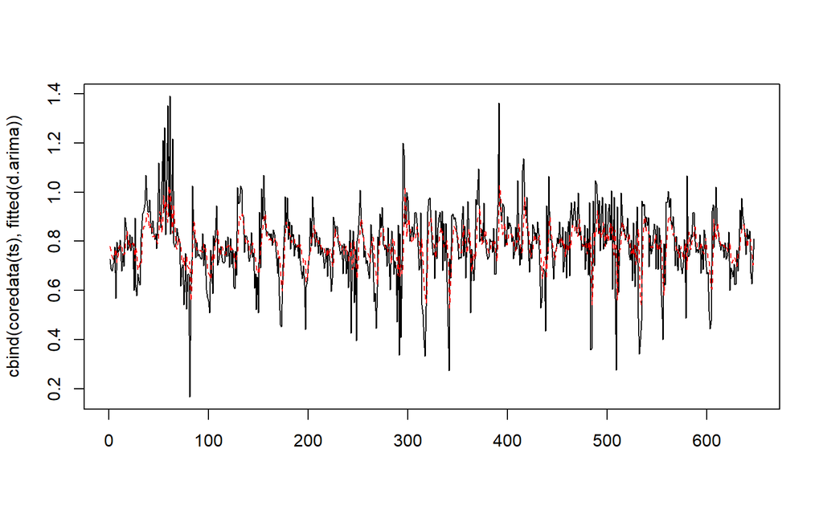

```r
matplot(cbind(coredata(ts),fitted(d.arima)),type='l')
```

## Ce que le sentiment aurait du être (contrefactuel)

La prédiction se fait aussi simplement que l’estimation du modèle avec forecast. On prédit autant de périodes que de périodes observées après le discours du Président Macron.

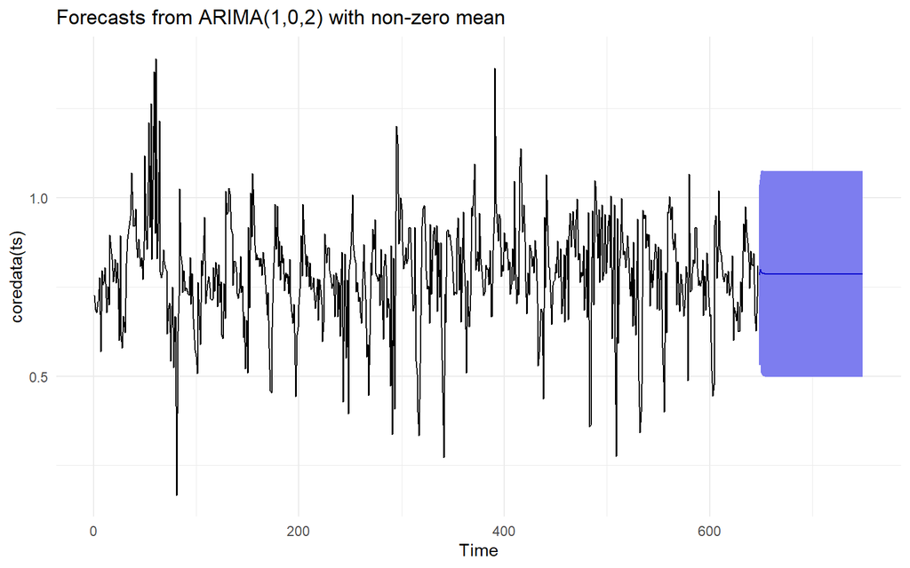

```r
d.forecast <- forecast(d.arima, level = c(95), h = 102)

autoplot(d.forecast)+theme_minimal()
```

## La comparison de la prédiction et des observations

On en représente le résultat en comparant les données observées à la prédiction et en examinant les écarts. On utilise une somme cumulative pour mieux marquer l’effet.

Elle doit être interprêté avec prudence.

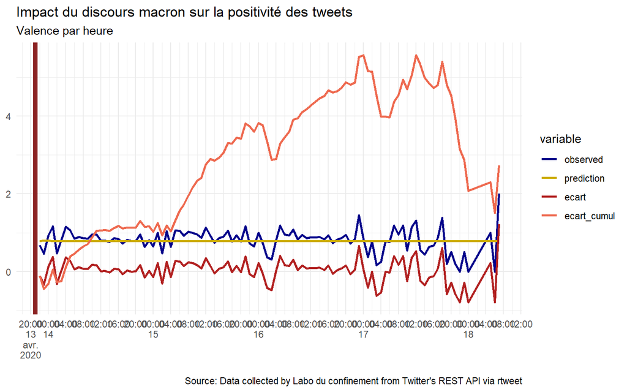

```r
foo2<-sentevol %>% ungroup %>% filter(date2>date_macron) %>% select(date2,negative,positive) %>% mutate(negative=-1*negative,  sentiment=positive+negative)
foop<-d.forecast[4]
foo2<-cbind(foo2, foop)%>% select(date2,positive, mean) %>% mutate(ecart=positive-mean, ecart_cumul=cumsum(ecart))%>%rename(prediction=mean, observed=positive)

col_macron<-c("darkblue","gold3","firebrick","coral2")
foo2<-melt(foo2, id="date2")
ggplot(foo2, aes(x=date2,y=value,group=variable))+
  geom_line(size=1,aes(color=variable))+
  theme(axis.text.x=element_text(angle = 60, vjust = 0.5))+
  theme_minimal()+# stat_smooth(  aes(color =variable, fill = variable),  method = "loess")+
  labs(x = NULL, y = NULL,
    title = "Impact du discours macron sur la positivité des tweets", y="Valence (+/-)",x="dates (par heures)",
    subtitle = "Valence par heure",
    caption = "\nSource: Data collected by Labo du confinement from Twitter's REST API via rtweet"
  )+  scale_x_datetime(date_breaks = "4 hour", labels = scales::label_date_short()) + geom_vline(xintercept = date_macron,  color = "brown4", size=2)+
  scale_colour_manual(values=col_macron)
```

## même procédure pour la negativity

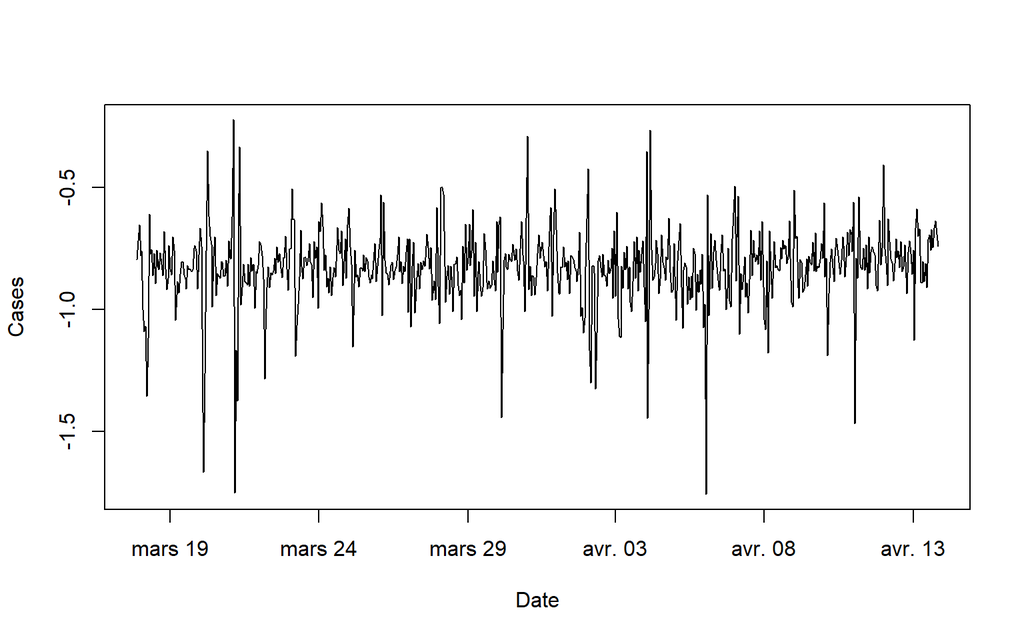

```r
library(zoo)
ts<- zoo(foo$negative, order.by=foo$date2)
plot(ts, xlab="Date", ylab="Cases")
```

[figure not shown]

```r
acf(coredata(ts),lag.max = 240, main="Temperature is Highly Autocorrelated!")
```

[figure not shown]

```r
pacf(coredata(ts),lag.max = 240, main="Temperature is Highly Autocorrelated!")
```

```r
mspect <- spec.pgram(coredata(ts))
```

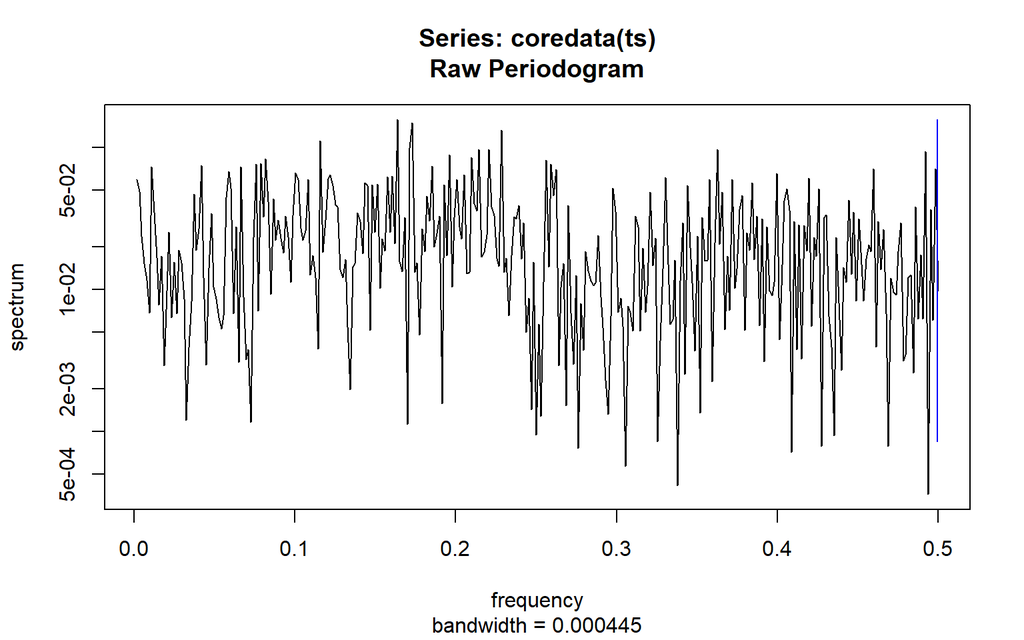

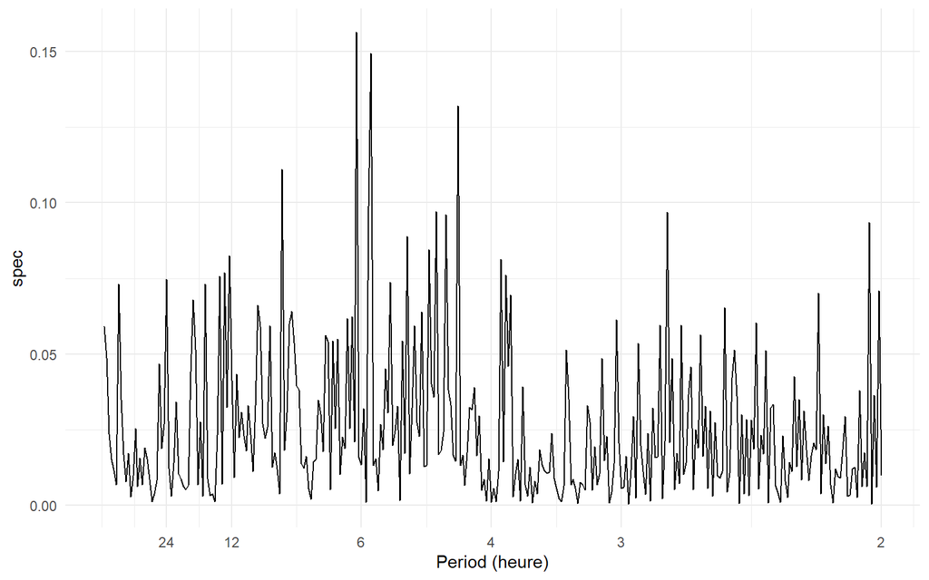

```r
#plot(mspect, log = "no")
#k = kernel("daniell", c(5,5))
#smooth.spec <- spec.pgram(coredata(ts), kernel = k, taper = 0)

spec.df <- data.frame(freq = mspect$freq, spec = mspect$spec)

day.period <- rev(c(1/24,1/12, 1/6,1, 2, 3, 4, 6, 12, 24))
day.labels <- rev(c("1/24","1/12", "1/6","1", "2", "3","4", "6", "12", "24"))
yrs.freqs <- 1/day.period  #Convert annual period to annual freq, and then to monthly freq
mspect$period <- 1/spec.df$freq

ggplot(data = spec.df)+ geom_line(aes(x = freq, y = spec)) + scale_x_continuous("Period (heure)",
    breaks = yrs.freqs, labels = day.labels) + scale_y_continuous() +theme_minimal()
```

```r
# from https://rstudio-pubs-static.s3.amazonaws.com/9428_1197bd003ebd43c49b429f22ea4f36e5.html
```

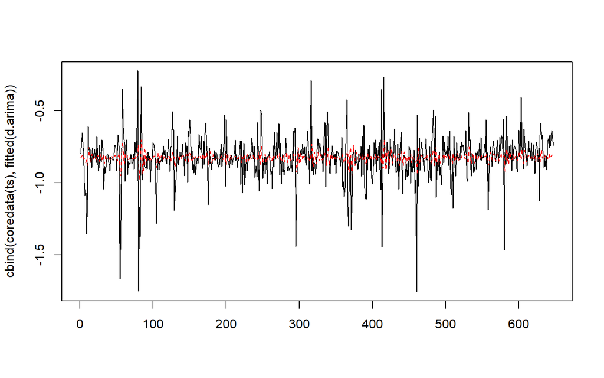

```r
library(forecast)
d.arima <- auto.arima(coredata(ts))
d.forecast <- forecast(d.arima, level = c(95), h = 102) #reajuster à chauqe maj des données
matplot(cbind(coredata(ts),fitted(d.arima)),type='l')
```

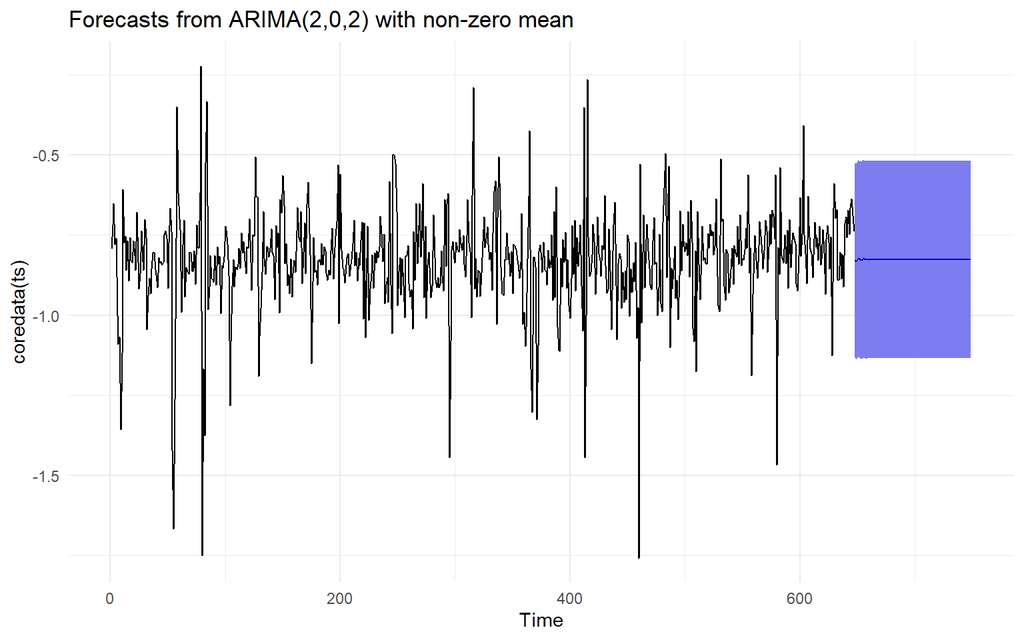

```r
autoplot(d.forecast)+theme_minimal()
```

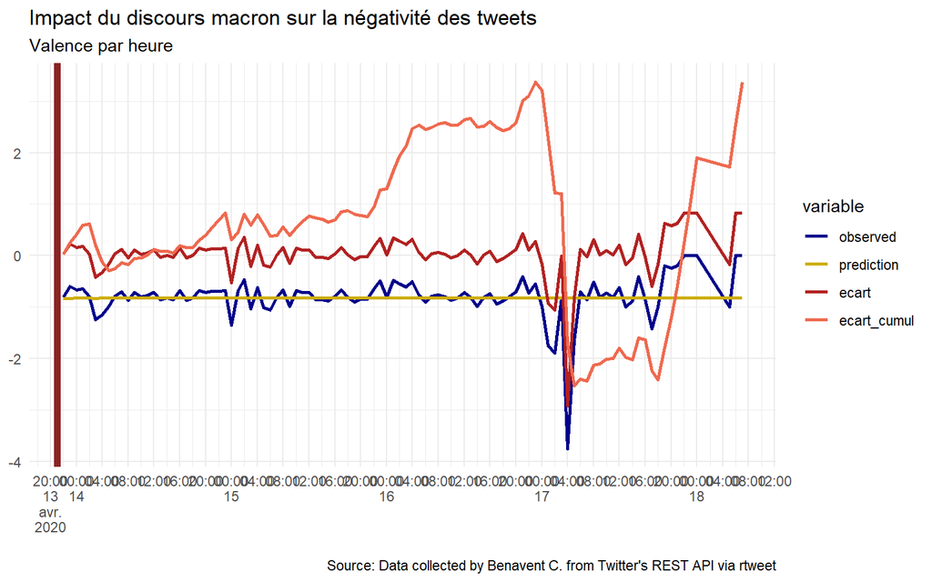

```r
foo2<-sentevol %>% ungroup %>% filter(date2>date_macron) %>% select(date2,negative,positive) %>% mutate(negative=-1*negative,  sentiment=positive+negative)
foop<-d.forecast[4]
foo2<-cbind(foo2, foop)%>% select(date2,negative, mean) %>% mutate(ecart=negative-mean, ecart_cumul=cumsum(ecart))%>%rename(prediction=mean, observed=negative)

foo2<-melt(foo2, id="date2")
col_macron<-c("darkblue","gold3","firebrick","coral2")

ggplot(foo2, aes(x=date2,y=value,group=variable))+
  geom_line(size=1,aes(color=variable))+
  theme(axis.text.x=element_text(angle = 60, vjust = 0.5))+
  theme_minimal()+# stat_smooth(  aes(color =variable, fill = variable),  method = "loess")+
  labs(x = NULL, y = NULL,
    title = "Impact du discours macron sur la négativité des tweets", y="Valence (+/-)",x="dates (par heures)",
    subtitle = "Valence par heure",
    caption = "\nSource: Data collected by Benavent C. from Twitter's REST API via rtweet"
  )+  scale_x_datetime(date_breaks = "4 hour", labels = scales::label_date_short()) + geom_vline(xintercept = date_macron,  color = "brown4", size=2)+scale_color_manual(values=col_macron)
```

# Conclusion

Des questions se posent et doivent être résolues:

- Examiner le rôle des superposteurs : des bots ? des spammeurs ? des trolls ?
- Affiner la relation entre l’expérience et le style.
- Un developpement serait de reconstituer les chaines de tweets.
- Se poser la question de l’élimination des superposteurs des analyses de contenu.